# Beyond the US: Replicating and Extending Benchmark Asset Pricing Factors Worldwide

Author

JKP data team

Published

July 15, 2026

**Contents**

- Data & method
- FF3 — Fama–French 3 factors
- FF5 — Fama–French 5 factors
- UMD — Fama–French momentum
- HXZ — q-factors
- MP — Stambaugh–Yuan mispricing factors
- DHS — Daniel–Hirshleifer–Sun behavioral factors
- Reasons for divergence
- Conclusion
- Appendix: Replication of daily data

## Introduction

This note documents our Python replication of several prominent asset pricing factor models and their extension to the international markets in the JKP database. We thank the [WRDS team](https://wrds-www.wharton.upenn.edu/pages/wrds-research/applications/risk-factors-and-industry-benchmarks/fama-french-factors-ciz-format/), as well as Professors [Kenneth R. French](https://mba.tuck.dartmouth.edu/pages/faculty/ken.french/data_library.html), [Robert F. Stambaugh](https://fnce.wharton.upenn.edu/profile/stambaug/), and [Lin Sun](https://sites.google.com/view/linsunhome), for providing the data and/or code that made this replication possible.

## Data & method

We assess the quality of our replication by comparing the US factors against the published reference series. For the international panels, no official reference data exist, so we make discretionary implementation choices that follow the spirit of the original US methodologies. Our implementation produces both the US and international factor return series, together with the underlying firm characteristics.

### Factors we replicate:

- **FF3** (Fama–French 1992, 1993, 2023) — SMB is the size factor (small minus big) and HML is the value factor (high minus low book-to-market), both constructed from a 2×3 size × book-to-market sort.
- **FF5** (Fama–French 2015) — SMB is the redefined size factor (averaged across 2×3 size × book-to-market, profitability, and investment sorts), HML is the value factor, RMW is the profitability factor (robust minus weak), and CMA is the investment factor (conservative minus aggressive).
- **UMD** (Carhart 1997) — UMD is the momentum factor (up minus down), constructed from prior 12-month returns excluding the most recent month within size buckets.
- **HXZ** q-factors (Hou, Xue, and Zhang 2015) — ME is the size factor, IA is the investment factor, and ROE is the profitability factor, all constructed from a 2×3×3 sort on size, investment-to-assets, and return on equity.
- **MP** (Stambaugh and Yuan 2017) — MGMT and PERF are long–short composite mispricing factors constructed from 11 anomalies grouped into management and performance clusters, while SMB is the size factor from the corresponding 2×3 size-by-mispricing sorts.
- **DHS** (Daniel, Hirshleifer, and Sun 2020) — FIN is the financing factor, constructed from the overlap of net stock issuance and composite share issuance, and PEAD is the post-earnings-announcement drift factor, constructed from cumulative abnormal returns around quarterly earnings announcements. Our implementation additionally produces daily FIN and PEAD factors. Because the original code does not provide daily reference series, these daily factors are not included in the Appendix.

## FF3 — Fama–French 3 factors

**SMB**

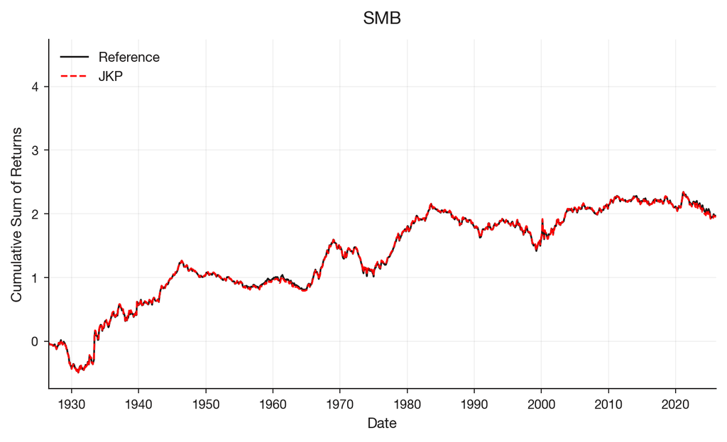

**HML**

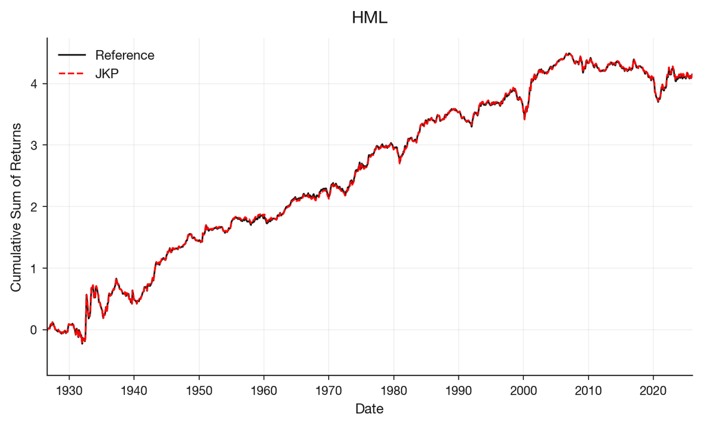

*Comparison window: USA, 1926-07-31 to 2025-12-31 (monthly, 1194 obs).*

*All Mean and StD figures are annualized.*

**Full sample**

| Factor | Mean JKP (%) | Mean Benchmark (%) | StD JKP (%) | StD Benchmark (%) | Corr (%) |
| --- | --- | --- | --- | --- | --- |
| SMB | 1.96 | 1.97 | 10.99 | 10.92 | 99.85 |
| HML | 4.17 | 4.17 | 12.35 | 12.31 | 99.78 |

**Breakdown by decade**

SMB

| Time Period | Mean JKP (%) | Mean Benchmark (%) | StD JKP (%) | StD Benchmark (%) | Corr (%) |
| --- | --- | --- | --- | --- | --- |
| 1920–1929 | -12.46 | -12.27 | 9.52 | 9.60 | 99.96 |
| 1930–1939 | 10.13 | 10.01 | 18.99 | 18.74 | 99.85 |
| 1940–1949 | 4.70 | 4.72 | 8.03 | 8.05 | 99.98 |
| 1950–1959 | -1.01 | -0.72 | 5.39 | 5.36 | 99.78 |
| 1960–1969 | 5.02 | 4.75 | 8.79 | 8.82 | 99.89 |
| 1970–1979 | 3.49 | 3.46 | 11.69 | 11.78 | 99.97 |
| 1980–1989 | -0.02 | -0.05 | 8.16 | 8.15 | 99.95 |
| 1990–1999 | -1.46 | -1.56 | 10.27 | 10.27 | 99.95 |
| 2000–2009 | 4.93 | 5.05 | 13.92 | 13.71 | 99.85 |
| 2010–2019 | -0.28 | -0.21 | 7.55 | 7.70 | 99.76 |
| 2020 to Present | -2.80 | -2.56 | 10.96 | 10.51 | 99.40 |

HML

| Time Period | Mean JKP (%) | Mean Benchmark (%) | StD JKP (%) | StD Benchmark (%) | Corr (%) |
| --- | --- | --- | --- | --- | --- |
| 1920–1929 | 2.48 | 2.49 | 8.92 | 8.80 | 99.91 |
| 1930–1939 | 3.97 | 3.98 | 25.75 | 25.71 | 99.85 |
| 1940–1949 | 9.72 | 9.67 | 9.26 | 9.24 | 99.96 |
| 1950–1959 | 3.89 | 3.55 | 7.86 | 7.84 | 99.77 |
| 1960–1969 | 2.81 | 3.45 | 6.59 | 6.60 | 99.48 |
| 1970–1979 | 7.98 | 7.85 | 9.50 | 9.47 | 99.89 |
| 1980–1989 | 6.06 | 5.93 | 9.51 | 9.61 | 99.90 |
| 1990–1999 | -0.01 | 0.05 | 9.04 | 9.03 | 99.77 |
| 2000–2009 | 8.05 | 7.94 | 13.02 | 12.77 | 99.71 |
| 2010–2019 | -2.33 | -2.35 | 8.04 | 7.88 | 99.55 |
| 2020 to Present | 0.83 | 0.86 | 15.33 | 15.43 | 99.53 |

## FF5 — Fama–French 5 factors

**SMB**

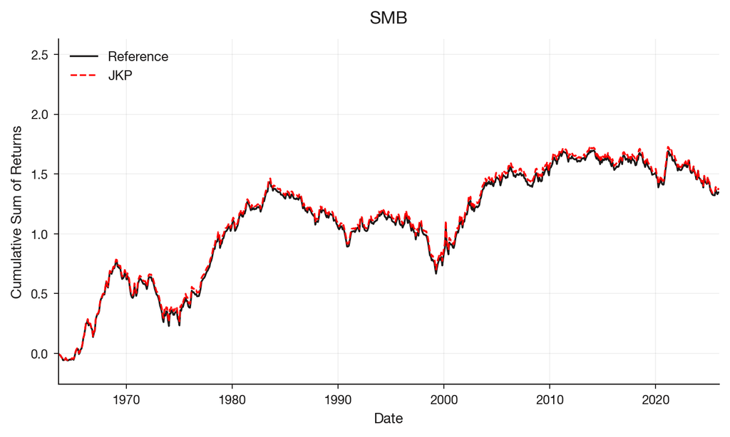

**HML**

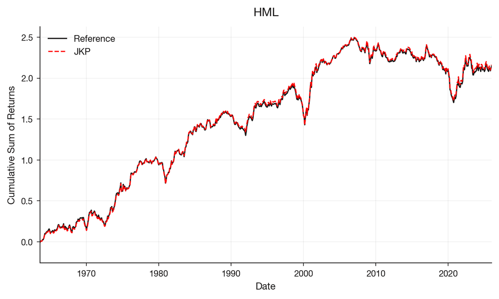

**RMW**

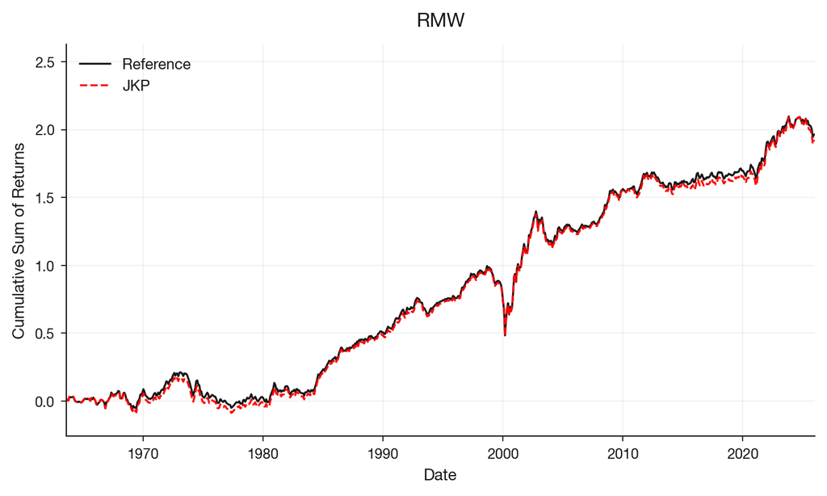

**CMA**

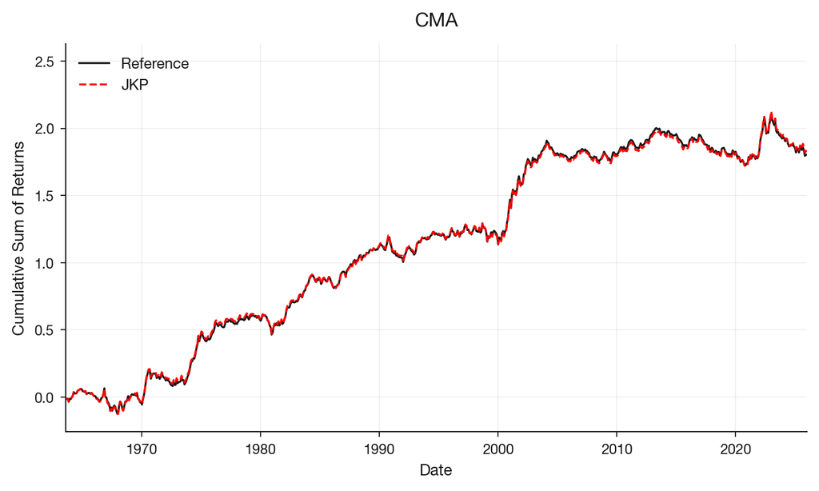

*Comparison window: USA, 1963-07-31 to 2025-12-31 (monthly, 750 obs).*

*All Mean and StD figures are annualized.*

**Full sample**

| Factor | Mean JKP (%) | Mean Benchmark (%) | StD JKP (%) | StD Benchmark (%) | Corr (%) |
| --- | --- | --- | --- | --- | --- |
| SMB | 2.20 | 2.15 | 10.47 | 10.49 | 99.90 |
| HML | 3.46 | 3.44 | 10.34 | 10.29 | 99.71 |
| RMW | 3.07 | 3.15 | 7.86 | 7.70 | 99.48 |
| CMA | 2.93 | 2.89 | 7.16 | 7.15 | 99.62 |

**Breakdown by decade**

SMB

| Time Period | Mean JKP (%) | Mean Benchmark (%) | StD JKP (%) | StD Benchmark (%) | Corr (%) |
| --- | --- | --- | --- | --- | --- |
| 1960–1969 | 9.80 | 9.50 | 10.03 | 10.10 | 99.92 |
| 1970–1979 | 4.77 | 4.74 | 12.13 | 12.21 | 99.98 |
| 1980–1989 | -0.39 | -0.42 | 8.15 | 8.15 | 99.95 |
| 1990–1999 | -1.94 | -2.07 | 9.99 | 10.01 | 99.97 |
| 2000–2009 | 7.07 | 7.08 | 12.68 | 12.66 | 99.95 |
| 2010–2019 | -0.44 | -0.37 | 7.73 | 7.89 | 99.83 |
| 2020 to Present | -2.84 | -2.78 | 11.71 | 11.47 | 99.61 |

HML

| Time Period | Mean JKP (%) | Mean Benchmark (%) | StD JKP (%) | StD Benchmark (%) | Corr (%) |
| --- | --- | --- | --- | --- | --- |
| 1960–1969 | 2.12 | 2.37 | 6.48 | 6.54 | 99.70 |
| 1970–1979 | 7.98 | 7.85 | 9.50 | 9.47 | 99.89 |
| 1980–1989 | 6.06 | 5.93 | 9.51 | 9.61 | 99.90 |
| 1990–1999 | -0.01 | 0.05 | 9.04 | 9.03 | 99.77 |
| 2000–2009 | 8.05 | 7.94 | 13.02 | 12.77 | 99.71 |
| 2010–2019 | -2.33 | -2.35 | 8.04 | 7.88 | 99.55 |
| 2020 to Present | 0.83 | 0.86 | 15.33 | 15.43 | 99.53 |

RMW

| Time Period | Mean JKP (%) | Mean Benchmark (%) | StD JKP (%) | StD Benchmark (%) | Corr (%) |
| --- | --- | --- | --- | --- | --- |
| 1960–1969 | 0.89 | 1.34 | 5.76 | 5.65 | 99.56 |
| 1970–1979 | -0.76 | -0.65 | 5.52 | 5.51 | 99.69 |
| 1980–1989 | 5.01 | 4.83 | 5.10 | 5.11 | 99.52 |
| 1990–1999 | 2.44 | 2.29 | 5.87 | 5.85 | 99.76 |
| 2000–2009 | 8.30 | 8.28 | 13.43 | 13.50 | 99.93 |
| 2010–2019 | 0.99 | 1.36 | 5.64 | 5.13 | 98.58 |
| 2020 to Present | 4.44 | 4.46 | 9.98 | 9.07 | 98.64 |

CMA

| Time Period | Mean JKP (%) | Mean Benchmark (%) | StD JKP (%) | StD Benchmark (%) | Corr (%) |
| --- | --- | --- | --- | --- | --- |
| 1960–1969 | -0.77 | -0.87 | 6.94 | 7.01 | 99.65 |
| 1970–1979 | 6.24 | 6.24 | 6.66 | 6.64 | 99.83 |
| 1980–1989 | 5.56 | 5.57 | 6.21 | 6.20 | 99.71 |
| 1990–1999 | 0.04 | 0.17 | 7.10 | 7.09 | 99.81 |
| 2000–2009 | 6.59 | 6.65 | 8.17 | 8.23 | 99.82 |
| 2010–2019 | 0.23 | 0.20 | 5.04 | 5.03 | 99.46 |
| 2020 to Present | 0.28 | -0.35 | 10.12 | 9.90 | 99.11 |

## UMD — Fama–French momentum

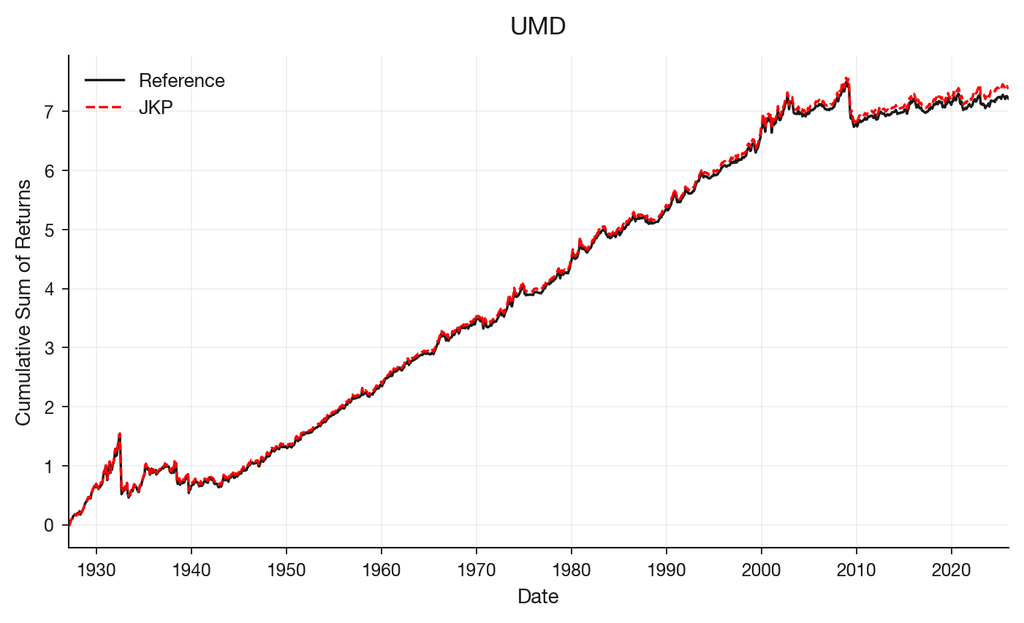

*Comparison window: USA, 1927-01-31 to 2025-12-31 (monthly, 1188 obs).*

*All Mean and StD figures are annualized.*

**Full sample**

| Factor | Mean JKP (%) | Mean Benchmark (%) | StD JKP (%) | StD Benchmark (%) | Corr (%) |
| --- | --- | --- | --- | --- | --- |
| UMD | 7.45 | 7.29 | 16.27 | 16.22 | 99.92 |

**Breakdown by decade**

UMD

| Time Period | Mean JKP (%) | Mean Benchmark (%) | StD JKP (%) | StD Benchmark (%) | Corr (%) |
| --- | --- | --- | --- | --- | --- |
| 1920–1929 | 23.20 | 22.93 | 8.86 | 9.21 | 99.07 |
| 1930–1939 | -0.05 | -0.36 | 33.27 | 33.03 | 99.93 |
| 1940–1949 | 6.68 | 6.68 | 9.47 | 9.45 | 99.95 |
| 1950–1959 | 10.62 | 10.60 | 7.85 | 7.85 | 99.97 |
| 1960–1969 | 11.06 | 10.98 | 9.33 | 9.35 | 99.98 |
| 1970–1979 | 9.84 | 9.82 | 13.05 | 13.08 | 99.99 |
| 1980–1989 | 9.05 | 9.00 | 12.30 | 12.29 | 99.97 |
| 1990–1999 | 13.50 | 13.40 | 11.13 | 11.11 | 99.96 |
| 2000–2009 | 1.11 | 0.97 | 23.68 | 23.70 | 99.98 |
| 2010–2019 | 3.21 | 3.13 | 10.88 | 10.91 | 99.95 |
| 2020 to Present | 3.04 | 1.79 | 14.44 | 14.21 | 99.52 |

## HXZ — q-factors

**ME**

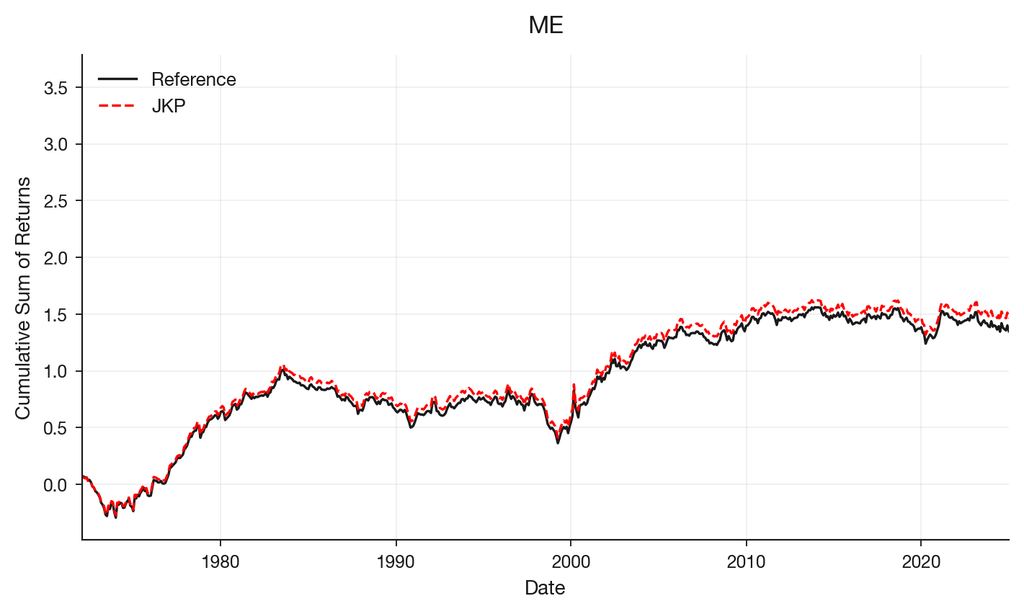

**IA**

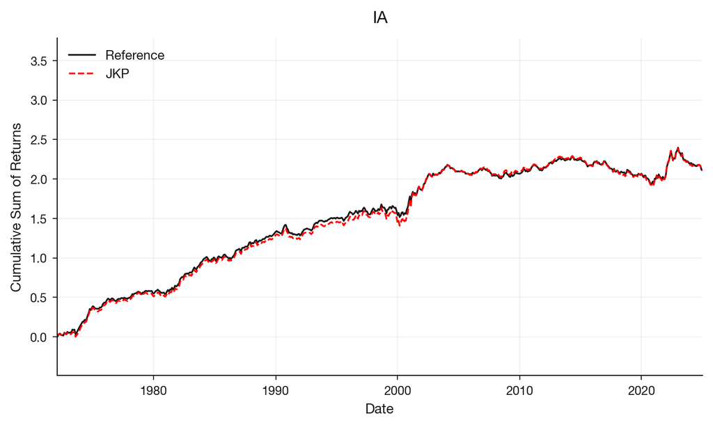

**ROE**

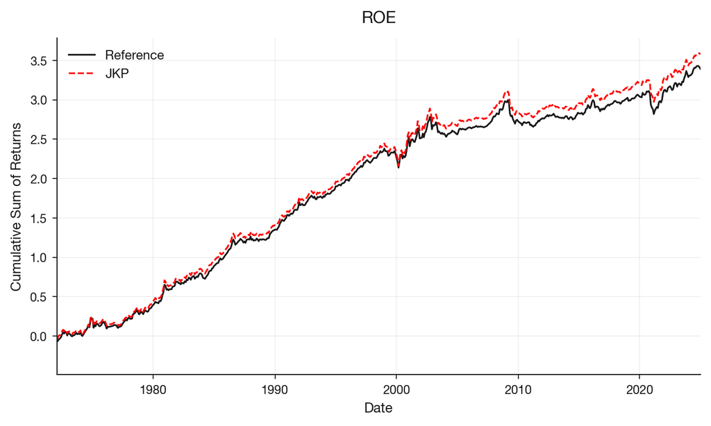

*All Mean and StD figures are annualized.*

**Full sample**

| Factor | Mean JKP (%) | Mean Benchmark (%) | StD JKP (%) | StD Benchmark (%) | Corr (%) |
| --- | --- | --- | --- | --- | --- |
| ME | 2.76 | 2.55 | 10.69 | 10.67 | 99.63 |
| IA | 3.98 | 3.99 | 7.54 | 7.13 | 98.15 |
| ROE | 6.75 | 6.40 | 9.35 | 9.19 | 98.84 |

**Breakdown by decade**

ME

| Time Period | Mean JKP (%) | Mean Benchmark (%) | StD JKP (%) | StD Benchmark (%) | Corr (%) |
| --- | --- | --- | --- | --- | --- |
| 1970–1979 | 8.45 | 7.98 | 12.46 | 12.45 | 99.77 |
| 1980–1989 | 0.25 | 0.08 | 8.16 | 8.02 | 99.42 |
| 1990–1999 | -0.81 | -0.96 | 10.22 | 10.03 | 99.63 |
| 2000–2009 | 8.47 | 8.46 | 13.18 | 13.37 | 99.71 |
| 2010–2019 | 0.02 | -0.12 | 8.16 | 8.09 | 99.53 |
| 2020–2024 | -0.14 | -0.72 | 11.59 | 11.67 | 99.48 |

IA

| Time Period | Mean JKP (%) | Mean Benchmark (%) | StD JKP (%) | StD Benchmark (%) | Corr (%) |
| --- | --- | --- | --- | --- | --- |
| 1970–1979 | 6.39 | 6.84 | 5.64 | 5.47 | 97.12 |
| 1980–1989 | 7.78 | 7.84 | 5.64 | 5.48 | 98.52 |
| 1990–1999 | 1.52 | 2.10 | 7.49 | 6.79 | 97.79 |
| 2000–2009 | 6.48 | 5.24 | 8.95 | 8.21 | 98.41 |
| 2010–2019 | -0.24 | 0.03 | 5.61 | 5.32 | 97.34 |
| 2020–2024 | 0.84 | 0.90 | 12.20 | 12.04 | 98.88 |

ROE

| Time Period | Mean JKP (%) | Mean Benchmark (%) | StD JKP (%) | StD Benchmark (%) | Corr (%) |
| --- | --- | --- | --- | --- | --- |
| 1970–1979 | 5.56 | 4.95 | 8.71 | 8.73 | 97.70 |
| 1980–1989 | 9.65 | 9.56 | 7.38 | 7.36 | 98.68 |
| 1990–1999 | 9.01 | 9.12 | 6.62 | 6.42 | 98.69 |
| 2000–2009 | 5.29 | 4.64 | 13.80 | 13.28 | 99.42 |
| 2010–2019 | 3.58 | 3.12 | 6.39 | 6.15 | 98.58 |
| 2020–2024 | 7.55 | 7.03 | 12.22 | 12.50 | 98.87 |

## MP — Stambaugh–Yuan mispricing factors

**SMB**

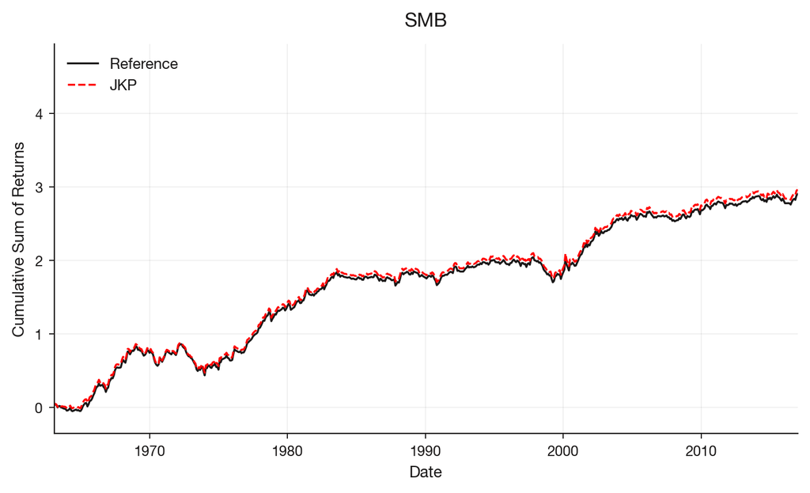

**MGMT**

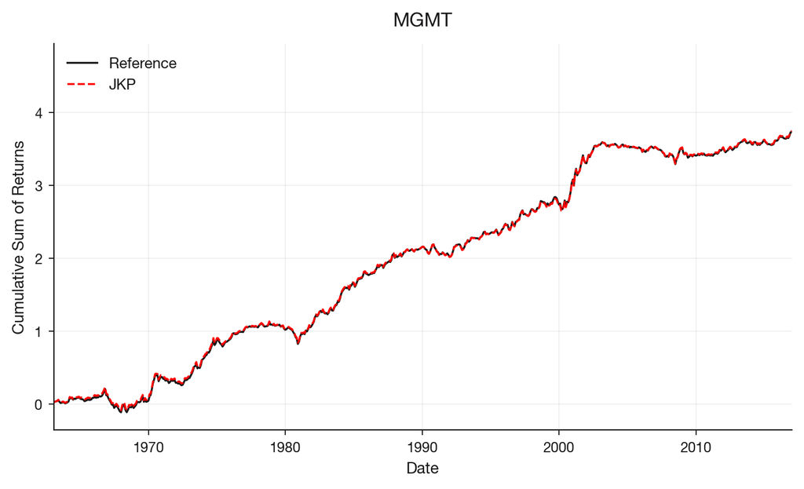

**PERF**

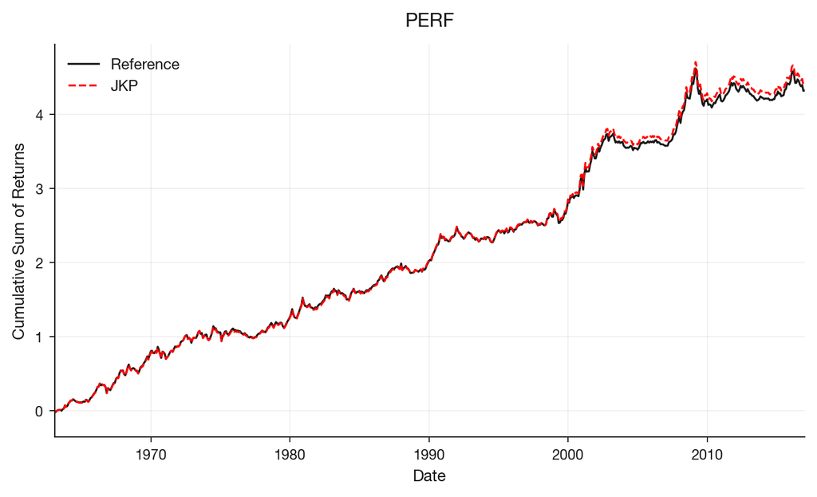

*Comparison window: USA, 1963-01-31 to 2016-12-31 (monthly, 648 obs).*

*All Mean and StD figures are annualized.*

**Full sample**

| Factor | Mean JKP (%) | Mean Benchmark (%) | StD JKP (%) | StD Benchmark (%) | Corr (%) |
| --- | --- | --- | --- | --- | --- |
| SMB | 5.49 | 5.38 | 9.88 | 9.88 | 99.86 |
| MGMT | 6.94 | 6.92 | 9.74 | 9.80 | 99.85 |
| PERF | 8.16 | 8.01 | 13.02 | 13.02 | 99.89 |

**Breakdown by decade**

SMB

| Time Period | Mean JKP (%) | Mean Benchmark (%) | StD JKP (%) | StD Benchmark (%) | Corr (%) |
| --- | --- | --- | --- | --- | --- |
| 1960–1969 | 10.87 | 10.57 | 10.06 | 10.08 | 99.63 |
| 1970–1979 | 6.63 | 6.36 | 11.93 | 11.90 | 99.88 |
| 1980–1989 | 3.84 | 3.89 | 8.50 | 8.47 | 99.88 |
| 1990–1999 | 0.88 | 0.70 | 8.79 | 8.74 | 99.89 |
| 2000–2009 | 8.54 | 8.51 | 11.14 | 11.21 | 99.92 |
| 2010–2016 | 3.08 | 3.08 | 7.54 | 7.56 | 99.91 |

MGMT

| Time Period | Mean JKP (%) | Mean Benchmark (%) | StD JKP (%) | StD Benchmark (%) | Corr (%) |
| --- | --- | --- | --- | --- | --- |
| 1960–1969 | 1.01 | 0.62 | 9.00 | 9.02 | 99.61 |
| 1970–1979 | 9.57 | 9.75 | 9.34 | 9.45 | 99.74 |
| 1980–1989 | 11.31 | 11.40 | 9.00 | 9.12 | 99.90 |
| 1990–1999 | 5.58 | 5.78 | 9.54 | 9.60 | 99.92 |
| 2000–2009 | 7.04 | 6.74 | 13.09 | 13.10 | 99.93 |
| 2010–2016 | 4.70 | 4.65 | 5.88 | 5.90 | 99.87 |

PERF

| Time Period | Mean JKP (%) | Mean Benchmark (%) | StD JKP (%) | StD Benchmark (%) | Corr (%) |
| --- | --- | --- | --- | --- | --- |
| 1960–1969 | 11.25 | 11.45 | 9.40 | 9.44 | 99.89 |
| 1970–1979 | 4.67 | 4.64 | 10.59 | 10.63 | 99.80 |
| 1980–1989 | 7.78 | 7.56 | 10.12 | 10.17 | 99.91 |
| 1990–1999 | 8.22 | 8.12 | 10.96 | 11.02 | 99.83 |
| 2000–2009 | 14.35 | 13.73 | 20.08 | 20.04 | 99.91 |
| 2010–2016 | 1.68 | 1.70 | 12.80 | 12.72 | 99.94 |

## DHS — Daniel–Hirshleifer–Sun behavioral factors

**FIN**

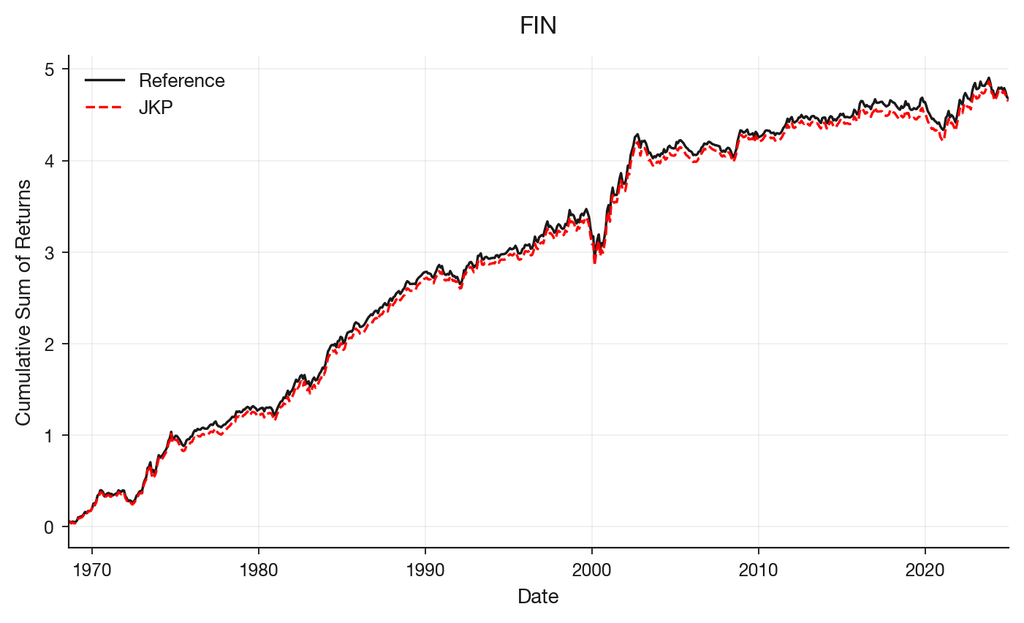

**PEAD**

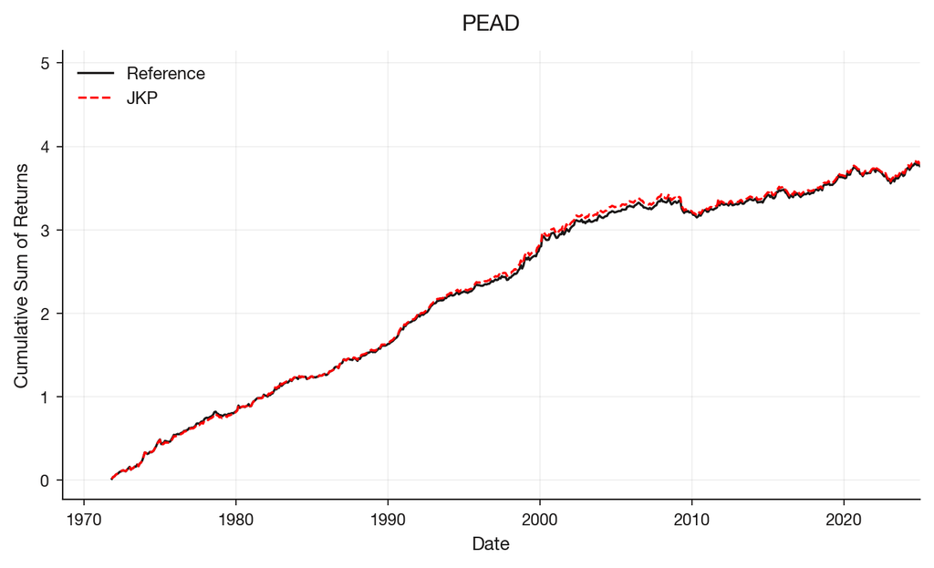

*Comparison window: USA, 1968-07-31 to 2024-12-31 (monthly, 678 obs).*

*All Mean and StD figures are annualized.*

**Full sample**

| Factor | Mean JKP (%) | Mean Benchmark (%) | StD JKP (%) | StD Benchmark (%) | Corr (%) |
| --- | --- | --- | --- | --- | --- |
| FIN | 8.23 | 8.29 | 13.20 | 13.19 | 99.49 |
| PEAD | 7.11 | 7.07 | 6.63 | 6.66 | 99.16 |

**Breakdown by decade**

FIN

| Time Period | Mean JKP (%) | Mean Benchmark (%) | StD JKP (%) | StD Benchmark (%) | Corr (%) |
| --- | --- | --- | --- | --- | --- |
| 1960–1969 | 13.57 | 13.60 | 5.95 | 5.82 | 98.20 |
| 1970–1979 | 10.15 | 10.76 | 10.78 | 10.39 | 99.23 |
| 1980–1989 | 14.94 | 15.03 | 9.81 | 9.69 | 99.43 |
| 1990–1999 | 3.75 | 3.81 | 12.35 | 12.70 | 99.62 |
| 2000–2009 | 11.18 | 10.89 | 20.04 | 20.04 | 99.92 |
| 2010–2019 | 3.16 | 3.85 | 9.40 | 9.33 | 99.63 |
| 2020 to Present | 2.56 | 0.85 | 15.63 | 15.69 | 98.25 |

PEAD

| Time Period | Mean JKP (%) | Mean Benchmark (%) | StD JKP (%) | StD Benchmark (%) | Corr (%) |
| --- | --- | --- | --- | --- | --- |
| 1970–1979 | 9.93 | 10.01 | 5.62 | 5.48 | 98.61 |
| 1980–1989 | 8.29 | 8.08 | 5.35 | 5.42 | 98.86 |
| 1990–1999 | 11.94 | 11.64 | 5.54 | 5.79 | 99.15 |
| 2000–2009 | 3.81 | 4.07 | 8.06 | 7.93 | 99.56 |
| 2010–2019 | 4.26 | 4.20 | 6.77 | 6.80 | 99.42 |
| 2020 to Present | 2.71 | 2.79 | 8.34 | 8.57 | 98.83 |

## Reasons for divergence

- **Compustat restatements.** Compustat is updated continuously, so accounting variables for older fiscal years get revised over time, which shifts any sort that conditions on accounting data.
- **Differences in CRSP Legacy vs CRSP V2.** Historical fields — delisting returns, share codes, exchange codes — differ between the two CRSP products.
- **Unspecified implementation choices.** The published methodology may not fully document every construction decision, making exact replication require original code and data vintage.

## Conclusion

Overall, the replicated JKP factor series closely track the published U.S. factors and are suitable for use as research substitutes. Beyond reproducing the U.S. factors, this project extends the methodology to the international sample, providing factors for countries where no comparable public benchmark is available. The entire construction process is open source and can be reproduced end-to-end from raw WRDS data.

Note on downstream characteristics. To improve consistency with the published factor series, we implemented several revisions to the factor construction methodology. As a result, these changes propagate to all factor-dependent characteristics and materially affect the values of the factors and characteristics associated with `mispricing_mgmt`, `mispricing_perf`, `iskew_ff3_21d`, `resff3_12_1`, `resff3_6_1`, `ivol_ff3_21d`, `iskew_hxz4_21d`, and `ivol_hxz4_21d` throughout the sample.

## Appendix: Replication of daily data

**Show daily replication tables**

Daily factor returns are mechanically noisier than monthly returns: small differences in universe filters, delisting handling, or trading calendars compound day-by-day, so day-level correlations are typically lower and day-level Mean / StD figures more dispersed than at the monthly frequency. The tables below mirror the monthly **breakdown by decade**, with a Full Sample row at the top, computed on daily data (Mean × 252, StD × √252).

### FF3

**SMB**

| Time Period | Mean JKP (%) | Mean Benchmark (%) | StD JKP (%) | StD Benchmark (%) | Corr (%) |
| --- | --- | --- | --- | --- | --- |
| Full Sample | 1.01 | 0.95 | 9.49 | 9.43 | 99.74 |
| 1920–1929 | -11.26 | -10.81 | 8.82 | 8.92 | 98.66 |
| 1930–1939 | 5.04 | 4.43 | 17.27 | 17.17 | 99.82 |
| 1940–1949 | 3.71 | 3.68 | 6.28 | 6.25 | 99.95 |
| 1950–1959 | -0.93 | -0.73 | 3.96 | 3.95 | 99.50 |
| 1960–1969 | 4.45 | 4.16 | 4.95 | 4.94 | 99.51 |
| 1970–1979 | 1.97 | 2.04 | 6.11 | 6.17 | 99.78 |
| 1980–1989 | -1.09 | -1.05 | 9.06 | 9.04 | 99.94 |
| 1990–1999 | -2.01 | -2.35 | 8.06 | 8.03 | 99.88 |
| 2000–2009 | 4.17 | 4.25 | 10.90 | 10.78 | 99.77 |
| 2010–2019 | -0.17 | -0.12 | 8.17 | 8.22 | 99.78 |
| 2020 to Present | -2.51 | -2.26 | 12.42 | 12.09 | 99.53 |

**HML**

| Time Period | Mean JKP (%) | Mean Benchmark (%) | StD JKP (%) | StD Benchmark (%) | Corr (%) |
| --- | --- | --- | --- | --- | --- |
| Full Sample | 3.70 | 3.73 | 10.00 | 9.94 | 99.64 |
| 1920–1929 | 2.84 | 2.18 | 8.00 | 7.71 | 98.88 |
| 1930–1939 | 0.47 | 0.44 | 17.39 | 17.24 | 99.73 |
| 1940–1949 | 8.27 | 8.20 | 7.85 | 7.83 | 99.95 |
| 1950–1959 | 3.47 | 3.23 | 5.39 | 5.34 | 99.35 |
| 1960–1969 | 2.75 | 3.55 | 4.73 | 4.74 | 98.79 |
| 1970–1979 | 7.91 | 7.95 | 5.74 | 5.69 | 99.44 |
| 1980–1989 | 6.20 | 6.21 | 6.68 | 6.66 | 99.75 |
| 1990–1999 | -0.03 | 0.19 | 7.18 | 7.12 | 99.58 |
| 2000–2009 | 8.78 | 8.64 | 12.59 | 12.45 | 99.68 |
| 2010–2019 | -2.37 | -2.36 | 8.14 | 7.99 | 99.64 |
| 2020 to Present | 0.51 | 0.57 | 17.08 | 17.30 | 99.63 |

### FF5

**SMB**

| Time Period | Mean JKP (%) | Mean Benchmark (%) | StD JKP (%) | StD Benchmark (%) | Corr (%) |
| --- | --- | --- | --- | --- | --- |
| Full Sample | 1.54 | 1.48 | 8.75 | 8.75 | 99.84 |
| 1960–1969 | 9.17 | 8.79 | 5.12 | 5.15 | 99.65 |
| 1970–1979 | 3.29 | 3.29 | 6.37 | 6.43 | 99.80 |
| 1980–1989 | -1.46 | -1.38 | 8.99 | 8.99 | 99.94 |
| 1990–1999 | -2.52 | -2.85 | 8.03 | 8.01 | 99.93 |
| 2000–2009 | 6.42 | 6.47 | 10.45 | 10.45 | 99.92 |
| 2010–2019 | -0.35 | -0.30 | 8.12 | 8.20 | 99.84 |
| 2020 to Present | -2.71 | -2.61 | 12.90 | 12.78 | 99.67 |

**HML**

| Time Period | Mean JKP (%) | Mean Benchmark (%) | StD JKP (%) | StD Benchmark (%) | Corr (%) |
| --- | --- | --- | --- | --- | --- |
| Full Sample | 3.54 | 3.61 | 9.32 | 9.30 | 99.62 |
| 1960–1969 | 1.95 | 2.44 | 4.72 | 4.73 | 99.29 |
| 1970–1979 | 7.91 | 7.95 | 5.74 | 5.69 | 99.44 |
| 1980–1989 | 6.20 | 6.21 | 6.68 | 6.66 | 99.75 |
| 1990–1999 | -0.03 | 0.19 | 7.18 | 7.12 | 99.58 |
| 2000–2009 | 8.78 | 8.64 | 12.59 | 12.45 | 99.68 |
| 2010–2019 | -2.37 | -2.36 | 8.14 | 7.99 | 99.64 |
| 2020 to Present | 0.51 | 0.57 | 17.08 | 17.30 | 99.63 |

**RMW**

| Time Period | Mean JKP (%) | Mean Benchmark (%) | StD JKP (%) | StD Benchmark (%) | Corr (%) |
| --- | --- | --- | --- | --- | --- |
| Full Sample | 3.12 | 3.22 | 6.57 | 6.42 | 99.28 |
| 1960–1969 | 0.99 | 1.48 | 3.91 | 3.89 | 98.86 |
| 1970–1979 | -0.64 | -0.58 | 3.83 | 3.83 | 98.92 |
| 1980–1989 | 4.91 | 4.92 | 3.75 | 3.74 | 98.87 |
| 1990–1999 | 2.71 | 2.50 | 4.61 | 4.56 | 99.52 |
| 2000–2009 | 8.79 | 8.87 | 10.21 | 10.23 | 99.84 |
| 2010–2019 | 0.84 | 1.16 | 5.75 | 5.49 | 98.77 |
| 2020 to Present | 3.70 | 3.77 | 11.00 | 10.27 | 98.97 |

**CMA**

| Time Period | Mean JKP (%) | Mean Benchmark (%) | StD JKP (%) | StD Benchmark (%) | Corr (%) |
| --- | --- | --- | --- | --- | --- |
| Full Sample | 2.95 | 2.94 | 6.11 | 6.08 | 99.37 |
| 1960–1969 | -0.62 | -0.82 | 5.01 | 4.94 | 99.12 |
| 1970–1979 | 6.39 | 6.49 | 4.66 | 4.72 | 98.93 |
| 1980–1989 | 5.49 | 5.75 | 4.67 | 4.66 | 99.45 |
| 1990–1999 | 0.30 | 0.39 | 6.22 | 6.15 | 99.69 |
| 2000–2009 | 6.42 | 6.42 | 7.76 | 7.77 | 99.74 |
| 2010–2019 | 0.18 | 0.14 | 4.72 | 4.78 | 99.21 |
| 2020 to Present | 0.06 | -0.58 | 9.32 | 9.11 | 99.03 |

### UMD

**UMD**

| Time Period | Mean JKP (%) | Mean Benchmark (%) | StD JKP (%) | StD Benchmark (%) | Corr (%) |
| --- | --- | --- | --- | --- | --- |
| Full Sample | 6.29 | 6.35 | 12.58 | 12.49 | 99.59 |
| 1920–1929 | 25.48 | 26.03 | 10.72 | 10.56 | 99.09 |
| 1930–1939 | -4.29 | -3.27 | 19.92 | 19.68 | 98.93 |
| 1940–1949 | 2.34 | 2.41 | 9.28 | 9.23 | 99.87 |
| 1950–1959 | 8.75 | 8.73 | 6.41 | 6.41 | 99.97 |
| 1960–1969 | 10.87 | 10.87 | 7.26 | 7.23 | 99.93 |
| 1970–1979 | 7.79 | 7.85 | 7.51 | 7.49 | 99.94 |
| 1980–1989 | 7.96 | 8.20 | 8.03 | 8.02 | 99.91 |
| 1990–1999 | 13.13 | 13.22 | 7.55 | 7.51 | 99.89 |
| 2000–2009 | 2.27 | 2.14 | 19.16 | 19.11 | 99.95 |
| 2010–2019 | 4.45 | 4.18 | 11.02 | 11.00 | 99.93 |
| 2020 to Present | 4.16 | 2.83 | 20.89 | 20.69 | 99.72 |

### HXZ

**ME**

| Time Period | Mean JKP (%) | Mean Benchmark (%) | StD JKP (%) | StD Benchmark (%) | Corr (%) |
| --- | --- | --- | --- | --- | --- |
| Full Sample | 1.93 | 1.77 | 9.21 | 9.24 | 99.42 |
| 1970–1979 | 6.60 | 6.30 | 6.74 | 6.78 | 98.84 |
| 1980–1989 | -0.86 | -1.06 | 8.79 | 8.84 | 99.48 |
| 1990–1999 | -1.71 | -1.79 | 7.95 | 7.95 | 99.31 |
| 2000–2009 | 7.67 | 7.74 | 10.85 | 10.96 | 99.51 |
| 2010–2019 | 0.11 | -0.01 | 8.51 | 8.50 | 99.53 |
| 2020–2024 | -0.45 | -1.06 | 12.84 | 12.85 | 99.50 |

**IA**

| Time Period | Mean JKP (%) | Mean Benchmark (%) | StD JKP (%) | StD Benchmark (%) | Corr (%) |
| --- | --- | --- | --- | --- | --- |
| Full Sample | 3.94 | 3.92 | 6.92 | 6.54 | 97.78 |
| 1970–1979 | 6.51 | 6.92 | 4.27 | 4.36 | 94.76 |
| 1980–1989 | 7.76 | 7.85 | 4.74 | 4.68 | 96.88 |
| 1990–1999 | 1.77 | 2.36 | 6.34 | 5.87 | 97.37 |
| 2000–2009 | 6.47 | 5.07 | 8.95 | 8.33 | 98.27 |
| 2010–2019 | -0.34 | -0.10 | 5.49 | 5.10 | 97.52 |
| 2020–2024 | 0.06 | 0.07 | 11.52 | 10.92 | 98.74 |

**ROE**

| Time Period | Mean JKP (%) | Mean Benchmark (%) | StD JKP (%) | StD Benchmark (%) | Corr (%) |
| --- | --- | --- | --- | --- | --- |
| Full Sample | 6.94 | 6.62 | 7.19 | 7.19 | 98.05 |
| 1970–1979 | 5.53 | 5.19 | 4.89 | 5.04 | 95.69 |
| 1980–1989 | 9.40 | 9.31 | 4.99 | 5.02 | 96.58 |
| 1990–1999 | 9.11 | 9.24 | 5.07 | 5.06 | 96.82 |
| 2000–2009 | 6.35 | 5.63 | 10.06 | 10.01 | 98.83 |
| 2010–2019 | 3.55 | 3.07 | 6.34 | 6.18 | 98.52 |
| 2020–2024 | 7.84 | 7.29 | 11.27 | 11.38 | 98.37 |

### MP

**SMB**

| Time Period | Mean JKP (%) | Mean Benchmark (%) | StD JKP (%) | StD Benchmark (%) | Corr (%) |
| --- | --- | --- | --- | --- | --- |
| Full Sample | 5.62 | 5.49 | 8.41 | 8.39 | 99.77 |
| 1960–1969 | 11.25 | 10.94 | 5.96 | 5.94 | 99.00 |
| 1970–1979 | 6.79 | 6.45 | 6.71 | 6.70 | 99.65 |
| 1980–1989 | 3.54 | 3.61 | 8.85 | 8.83 | 99.88 |
| 1990–1999 | 1.49 | 1.34 | 8.20 | 8.19 | 99.86 |
| 2000–2009 | 8.35 | 8.29 | 10.74 | 10.71 | 99.80 |
| 2010–2016 | 3.44 | 3.39 | 8.50 | 8.49 | 99.92 |

**MGMT**

| Time Period | Mean JKP (%) | Mean Benchmark (%) | StD JKP (%) | StD Benchmark (%) | Corr (%) |
| --- | --- | --- | --- | --- | --- |
| Full Sample | 6.88 | 6.85 | 8.17 | 8.19 | 99.79 |
| 1960–1969 | 1.18 | 0.77 | 6.64 | 6.65 | 99.47 |
| 1970–1979 | 9.89 | 10.03 | 6.68 | 6.71 | 99.62 |
| 1980–1989 | 11.10 | 11.16 | 7.20 | 7.24 | 99.79 |
| 1990–1999 | 5.38 | 5.62 | 8.05 | 8.08 | 99.90 |
| 2000–2009 | 6.83 | 6.50 | 11.80 | 11.83 | 99.84 |
| 2010–2016 | 4.39 | 4.36 | 6.39 | 6.41 | 99.90 |

**PERF**

| Time Period | Mean JKP (%) | Mean Benchmark (%) | StD JKP (%) | StD Benchmark (%) | Corr (%) |
| --- | --- | --- | --- | --- | --- |
| Full Sample | 7.63 | 7.51 | 11.94 | 11.93 | 99.84 |
| 1960–1969 | 11.08 | 11.29 | 6.36 | 6.42 | 99.63 |
| 1970–1979 | 4.10 | 4.09 | 6.23 | 6.23 | 99.37 |
| 1980–1989 | 7.34 | 7.11 | 6.19 | 6.23 | 99.70 |
| 1990–1999 | 7.47 | 7.47 | 7.92 | 7.86 | 99.59 |
| 2000–2009 | 13.49 | 12.91 | 22.32 | 22.28 | 99.91 |
| 2010–2016 | 1.56 | 1.61 | 12.16 | 12.21 | 99.91 |

## References

Carhart, M.M. (1997) ‘On persistence in mutual fund performance’, *The Journal of Finance*, 52(1), pp. 57–82. Available at: https://doi.org/10.1111/j.1540-6261.1997.tb03808.x.

Daniel, K., Hirshleifer, D. and Sun, L. (2020) ‘Short- and long-horizon behavioral factors’, *The Review of Financial Studies*, 33(4), pp. 1673–1736. Available at: https://doi.org/10.1093/rfs/hhz069.

Fama, E.F. and French, K.R. (1993) ‘Common risk factors in the returns on stocks and bonds’, *Journal of Financial Economics*, 33(1), pp. 3–56. Available at: https://doi.org/10.1016/0304-405X(93)90023-5.

Fama, E.F. and French, K.R. (2015) ‘A five-factor asset pricing model’, *Journal of Financial Economics*, 116(1), pp. 1–22. Available at: https://doi.org/10.1016/j.jfineco.2014.10.010.

Fama, E.F. and French, K.R. (2023) *Production of U.S. Rm-Rf, SMB, and HML in the Fama-French Data Library*. Chicago Booth Research Paper No. 23-22. Available at: https://doi.org/10.2139/ssrn.4629613.

Hou, K., Xue, C. and Zhang, L. (2015) ‘Digesting anomalies: An investment approach’, *The Review of Financial Studies*, 28(3), pp. 650–705. Available at: https://doi.org/10.1093/rfs/hhu068.

Jensen, T.I., Kelly, B. and Pedersen, L.H. (2023) ‘Is there a replication crisis in finance?’, *The Journal of Finance*, 78(5), pp. 2465–2518. Available at: https://doi.org/10.1111/jofi.13249.

Stambaugh, R.F. and Yuan, Y. (2017) ‘Mispricing factors’, *The Review of Financial Studies*, 30(4), pp. 1270–1315. Available at: https://doi.org/10.1093/rfs/hhw107.